# Machine Learning with R software

En esta práctica exploraremos por primera vez como es generar modelos mediante software de programación, en concreto en el lenguaje R mediante la intefaz RStudio.

## Dataset de trabajo

Primeramente deberemos inicializar la carpeta de trabajo, en ella estará el fichero iris.csv que contiene el dataset con el cual trabajaremos en este laboratorio

```r
setwd("/home/hidalgo/Ing.Inf/MDD/RStudio")
```

Una vez en la carpeta de trabajo leeremos el fichero.

```r
iris<-read.csv("iris.csv", header=TRUE, sep=",")
```

Podemos ver que pinta tiene nuestro dataset usando diferentes comandos de R:

- summary() nos dará datos estadísticos para cada columna: media, mín-máx, cuartiles…

```r
summary(iris)
```

```
##   sepal.length    sepal.width     petal.length    petal.width
##  Min.   :4.300   Min.   :2.000   Min.   :1.000   Min.   :0.100
##  1st Qu.:5.100   1st Qu.:2.800   1st Qu.:1.600   1st Qu.:0.300
##  Median :5.800   Median :3.000   Median :4.350   Median :1.300
##  Mean   :5.843   Mean   :3.057   Mean   :3.758   Mean   :1.199
##  3rd Qu.:6.400   3rd Qu.:3.300   3rd Qu.:5.100   3rd Qu.:1.800
##  Max.   :7.900   Max.   :4.400   Max.   :6.900   Max.   :2.500
##    variety
##  Length:150
##  Class :character
##  Mode  :character
##
##
##
```

- names() nos dará el nombre de las columnas de nuestro dataset.

```r
names(iris)
```

```
## [1] "sepal.length" "sepal.width"  "petal.length" "petal.width"  "variety"
```

Dado que estamos ante un problema de clasificación estas serán nuestras variables predictoras.

- head() nos mostrará cuales son los valores de cada columna para las primeras filas.

```r
head(iris)
```

```
##   sepal.length sepal.width petal.length petal.width variety
## 1          5.1         3.5          1.4         0.2  Setosa
## 2          4.9         3.0          1.4         0.2  Setosa
## 3          4.7         3.2          1.3         0.2  Setosa
## 4          4.6         3.1          1.5         0.2  Setosa
## 5          5.0         3.6          1.4         0.2  Setosa
## 6          5.4         3.9          1.7         0.4  Setosa
```

Como hemos podido ver la ultima columna del dataset es la clase del individuo, el nombre de la variedad de flor, y es por supuesto una clase nominal. Para poder trabajar mejor con el dataset convertiremos la variable en numérica.

```r
iris$variety <- as.factor(iris$variety)
table(iris$variety)
```

```
##
##     Setosa Versicolor  Virginica
##         50         50         50
```

Como podemos ver tenemos un dataset perfectamente balanceado, con 50 individuos en cada clase,

## Libreria caret

Para construir nuestro modelo utilizaremos el paquete de R caret, que contiene funciones para clasificación y regresión. Por tanto vamos a importar el paquete con el comando library().

```r
library(caret)
```

## Construcción del modelo

Para empezar determinaremos una semilla inicial, en función de ella se crearán las particiones de train y test para el modelo.

```r
set.seed("1234567890")
```

Una vez definida la semilla crearemos las particiones con el método createDataPartition()

```r
trainSetIndexes <- createDataPartition(y=iris$variety,p=.66,list=FALSE)
```

Es importante entender que parámetros recoge esta función y como cambia la salida en función de ellos

- y $\rightarrow$ variable que contiene los elementos a particionar.
- p $\rightarrow$ porcentaje de los casos que ira al subset de training.
- list $\rightarrow$ si especificamos FALSE para este parámetro devolverá la particián en una matriz en lugar de en un vector.

Usando la variable en la que guardamos la partición y su negada como índice para el dataset obtenemos las dos particiones.

```r
trainSet <- iris[trainSetIndexes,]
testSet <- iris[-trainSetIndexes,]
```

Numero de elementos del subconjunto trainSet: 99

Numero de elementos del subconjunto testSet: 51

Guardaremos en la variable ctrl los parámetros que tendrá nuestro clasificador, en nuestro caso un KNN.

```r
ctrl <- trainControl("cv", number=10)
```

- cv $\rightarrow$ método de clasificacion supervisada cross-validation
- number $\rightarrow$ valor para el hiperparametro del método de clasificación (en el caso del CV el número de hojas).

Por último la función train() es la que genera el clasificador juntando todas las piezas que hemos generado hasta ahora.

```r
KNNModel1 <- train(variety ~ ., data=trainSet, method="knn", tuneLength=5, trControl=ctrl, preProc=c("center","scale"))
```

La clase a predecir se marca en el primer parametro y separado por el caracter ~ se especifican las predictoras. Estos son los parámetros más importantes que toma:

- method $\rightarrow$ especifica que metodo de clasificación se va a usar para crear el clasificador.
- tuneLength $\rightarrow$ se usa para especificar para cuantos parámetros diferentes se probará el modelo. En nuestro caso se probarán 5 valores diferentes para K y el modelo se quedará con el que tenga mejor accuracy.
- trControl $\rightarrow$ trControl especifica que parametros queremos que tenga el clasificador, se usan los parametros ya especificados previamente.
- preProc $\rightarrow$ expresa el pre procesado previo que se le realiza a nuestros datos antes de entrenar el clasificador.

```r
KNNModel1
```

```
## k-Nearest Neighbors
##
## 99 samples
##  4 predictor
##  3 classes: 'Setosa', 'Versicolor', 'Virginica'
##
## Pre-processing: centered (4), scaled (4)
## Resampling: Cross-Validated (10 fold)
## Summary of sample sizes: 89, 90, 88, 89, 90, 89, ...
## Resampling results across tuning parameters:
##
##   k   Accuracy   Kappa
##    5  0.9386869  0.9073918
##    7  0.9509091  0.9255736
##    9  0.9609091  0.9407251
##   11  0.9497980  0.9240585
##   13  0.9275758  0.8907251
##
## Accuracy was used to select the optimal model using the largest value.
## The final value used for the model was k = 9.
```

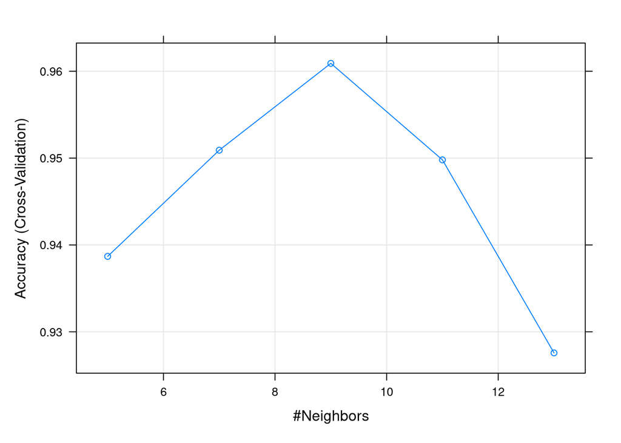

```r
plot(KNNModel1)
```

Usando el subconjunto de test y el modelo generado podemos ver cual es su fiabilidad para conjunto de individuos nuevo.

```r
KNNPredict1 <- predict(KNNModel1, newdata=testSet)
confusionMatrix(KNNPredict1, testSet$variety)
```

```
## Confusion Matrix and Statistics
##
##             Reference
## Prediction   Setosa Versicolor Virginica
##   Setosa         17          0         0
##   Versicolor      0         17         1
##   Virginica       0          0        16
##
## Overall Statistics
##
##                Accuracy : 0.9804
##                  95% CI : (0.8955, 0.9995)
##     No Information Rate : 0.3333
##     P-Value [Acc > NIR] : < 2.2e-16
##
##                   Kappa : 0.9706
##
##  Mcnemar's Test P-Value : NA
##
## Statistics by Class:
##
##                      Class: Setosa Class: Versicolor Class: Virginica
## Sensitivity                 1.0000            1.0000           0.9412
## Specificity                 1.0000            0.9706           1.0000
## Pos Pred Value              1.0000            0.9444           1.0000
## Neg Pred Value              1.0000            1.0000           0.9714
## Prevalence                  0.3333            0.3333           0.3333
## Detection Rate              0.3333            0.3333           0.3137
## Detection Prevalence        0.3333            0.3529           0.3137
## Balanced Accuracy           1.0000            0.9853           0.9706
```

Si nos fijamos la matriz de confusión que nos da R está traspuesta en comparación con la que nos devolvía Weka, es decir las columnas son las clases reales y las filas las clases predecidas.

Para un segundo ejemplo, en lugar de usar tuneLength para especificar el número de valores diferentes que tomará el parámetro del modelo, usaremos tuneGrid; con el que podremos elegir con que valores específicos se probará el clasificador.

```r
KNNModel2 <- train(variety ~ ., data=trainSet, method="knn", tuneGrid = expand.grid(k = c(1, 3, 5, 15, 19)), trControl=ctrl, preProc=c("center","scale"))
KNNModel2
```

```
## k-Nearest Neighbors
##
## 99 samples
##  4 predictor
##  3 classes: 'Setosa', 'Versicolor', 'Virginica'
##
## Pre-processing: centered (4), scaled (4)
## Resampling: Cross-Validated (10 fold)
## Summary of sample sizes: 89, 90, 89, 87, 90, 89, ...
## Resampling results across tuning parameters:
##
##   k   Accuracy   Kappa
##    1  0.9392424  0.9089944
##    3  0.9614646  0.9423277
##    5  0.9514646  0.9271762
##   15  0.9314646  0.8964070
##   19  0.9405556  0.9099872
##
## Accuracy was used to select the optimal model using the largest value.
## The final value used for the model was k = 3.
```

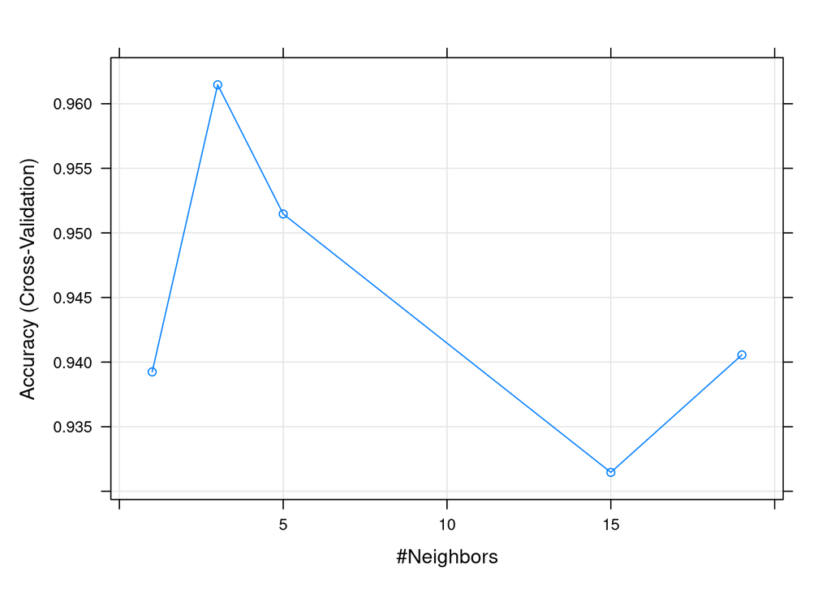

```r
plot(KNNModel2)
```

Hemos probado el clasificador para los valores [1,3,5,15,19] y dado que el accuracy más alto se ha conseguido para K=3, como se puede ver en la gráfica, el modelo se ha decantado por ese valor.

```r
KNNPredict2 <- predict(KNNModel2, newdata=testSet)
confusionMatrix(KNNPredict2, testSet$variety)
```

```
## Confusion Matrix and Statistics
##
##             Reference
## Prediction   Setosa Versicolor Virginica
##   Setosa         16          0         0
##   Versicolor      1         16         2
##   Virginica       0          1        15
##
## Overall Statistics
##
##                Accuracy : 0.9216
##                  95% CI : (0.8112, 0.9782)
##     No Information Rate : 0.3333
##     P-Value [Acc > NIR] : < 2.2e-16
##
##                   Kappa : 0.8824
##
##  Mcnemar's Test P-Value : NA
##
## Statistics by Class:
##
##                      Class: Setosa Class: Versicolor Class: Virginica
## Sensitivity                 0.9412            0.9412           0.8824
## Specificity                 1.0000            0.9118           0.9706
## Pos Pred Value              1.0000            0.8421           0.9375
## Neg Pred Value              0.9714            0.9687           0.9429
## Prevalence                  0.3333            0.3333           0.3333
## Detection Rate              0.3137            0.3137           0.2941
## Detection Prevalence        0.3137            0.3725           0.3137
## Balanced Accuracy           0.9706            0.9265           0.9265
```

# Clasificadores Naïve Bayes y árbol de clasificación

```r
library(naivebayes)
nb_grid <-   expand.grid(usekernel = c(TRUE, FALSE),
                         laplace = c(0, 0.5, 1),
                         adjust = c(0.75, 1, 1.25, 1.5))
naiveBayes <- train(variety ~ .,data=trainSet,method="naive_bayes",usepoisson=TRUE,tuneGrid=nb_grid)
naiveBayes
```

```
## Naive Bayes
##
## 99 samples
##  4 predictor
##  3 classes: 'Setosa', 'Versicolor', 'Virginica'
##
## No pre-processing
## Resampling: Bootstrapped (25 reps)
## Summary of sample sizes: 99, 99, 99, 99, 99, 99, ...
## Resampling results across tuning parameters:
##
##   usekernel  laplace  adjust  Accuracy   Kappa
##   FALSE      0.0      0.75    0.9447651  0.9159064
##   FALSE      0.0      1.00    0.9447651  0.9159064
##   FALSE      0.0      1.25    0.9447651  0.9159064
##   FALSE      0.0      1.50    0.9447651  0.9159064
##   FALSE      0.5      0.75    0.9447651  0.9159064
##   FALSE      0.5      1.00    0.9447651  0.9159064
##   FALSE      0.5      1.25    0.9447651  0.9159064
##   FALSE      0.5      1.50    0.9447651  0.9159064
##   FALSE      1.0      0.75    0.9447651  0.9159064
##   FALSE      1.0      1.00    0.9447651  0.9159064
##   FALSE      1.0      1.25    0.9447651  0.9159064
##   FALSE      1.0      1.50    0.9447651  0.9159064
##    TRUE      0.0      0.75    0.9447096  0.9155881
##    TRUE      0.0      1.00    0.9468734  0.9188800
##    TRUE      0.0      1.25    0.9467999  0.9190497
##    TRUE      0.0      1.50    0.9457472  0.9174713
##    TRUE      0.5      0.75    0.9447096  0.9155881
##    TRUE      0.5      1.00    0.9468734  0.9188800
##    TRUE      0.5      1.25    0.9467999  0.9190497
##    TRUE      0.5      1.50    0.9457472  0.9174713
##    TRUE      1.0      0.75    0.9447096  0.9155881
##    TRUE      1.0      1.00    0.9468734  0.9188800
##    TRUE      1.0      1.25    0.9467999  0.9190497
##    TRUE      1.0      1.50    0.9457472  0.9174713
##
## Accuracy was used to select the optimal model using the largest value.
## The final values used for the model were laplace = 0, usekernel = TRUE
##  and adjust = 1.
```

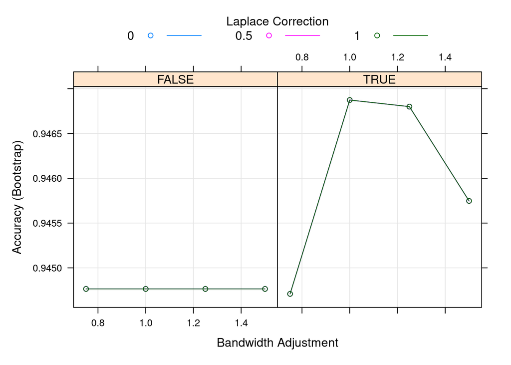

```r
plot(naiveBayes)
```

```r
naiveBayesPredict <- predict(naiveBayes,newdata=testSet)
confusionMatrix(naiveBayesPredict,testSet$variety)
```

```
## Confusion Matrix and Statistics
##
##             Reference
## Prediction   Setosa Versicolor Virginica
##   Setosa         17          0         0
##   Versicolor      0         16         1
##   Virginica       0          1        16
##
## Overall Statistics
##
##                Accuracy : 0.9608
##                  95% CI : (0.8654, 0.9952)
##     No Information Rate : 0.3333
##     P-Value [Acc > NIR] : < 2.2e-16
##
##                   Kappa : 0.9412
##
##  Mcnemar's Test P-Value : NA
##
## Statistics by Class:
##
##                      Class: Setosa Class: Versicolor Class: Virginica
## Sensitivity                 1.0000            0.9412           0.9412
## Specificity                 1.0000            0.9706           0.9706
## Pos Pred Value              1.0000            0.9412           0.9412
## Neg Pred Value              1.0000            0.9706           0.9706
## Prevalence                  0.3333            0.3333           0.3333
## Detection Rate              0.3333            0.3137           0.3137
## Detection Prevalence        0.3333            0.3333           0.3333
## Balanced Accuracy           1.0000            0.9559           0.9559
```

```r
#library(RWeka)

#decisionTree <- train(variety ~ .,data=trainSet,method="J48")
#decisionTree
#plot(decisionTree)

#decisionTreePredict <- predict(decisionTree,newdata=testSet)
#confusionMatrix(decisionTreePredict,testSet$variety)
```